# Risk Factor Analysis

## Outcome Variable

**Outcome Variable:** wast_rec90d

## Predictor Variables

**Intervention Variable:** earlybf

**Adjustment Set:**

- arm
- sex
- W_mage
- meducyrs
- feducyrs
- hhwealth_quart
- hfoodsec
- W_mhtcm
- vagbrth
- W_birthwt
- W_birthlen
- W_nrooms
- W_nchldlt5
- brthmon
- W_parity
- impfloor
- impsan
- safeh20
- delta_W_mage
- delta_meducyrs
- delta_feducyrs
- delta_hhwealth_quart
- delta_hfoodsec
- delta_W_mhtcm
- delta_vagbrth
- delta_W_birthwt
- delta_W_birthlen
- delta_W_nrooms
- delta_W_nchldlt5
- delta_brthmon
- delta_W_parity
- delta_impfloor
- delta_impsan
- delta_safeh20

## Stratifying Variables

The analysis was stratified on these variable(s):

- agecat
- studyid
- country

## Data Summary

| agecat | studyid | country | earlybf | wast_rec90d | n_cell | n |
| --- | --- | --- | --- | --- | --- | --- |
| 0-24 months | ki0047075b-MAL-ED | BANGLADESH | 0 | 0 | 18 | 122 |
| 0-24 months | ki0047075b-MAL-ED | BANGLADESH | 0 | 1 | 32 | 122 |
| 0-24 months | ki0047075b-MAL-ED | BANGLADESH | 1 | 0 | 26 | 122 |
| 0-24 months | ki0047075b-MAL-ED | BANGLADESH | 1 | 1 | 46 | 122 |
| 0-24 months | ki0047075b-MAL-ED | BRAZIL | 0 | 0 | 3 | 23 |
| 0-24 months | ki0047075b-MAL-ED | BRAZIL | 0 | 1 | 12 | 23 |
| 0-24 months | ki0047075b-MAL-ED | BRAZIL | 1 | 0 | 3 | 23 |
| 0-24 months | ki0047075b-MAL-ED | BRAZIL | 1 | 1 | 5 | 23 |
| 0-24 months | ki0047075b-MAL-ED | INDIA | 0 | 0 | 27 | 178 |
| 0-24 months | ki0047075b-MAL-ED | INDIA | 0 | 1 | 45 | 178 |
| 0-24 months | ki0047075b-MAL-ED | INDIA | 1 | 0 | 44 | 178 |
| 0-24 months | ki0047075b-MAL-ED | INDIA | 1 | 1 | 62 | 178 |
| 0-24 months | ki0047075b-MAL-ED | NEPAL | 0 | 0 | 11 | 93 |
| 0-24 months | ki0047075b-MAL-ED | NEPAL | 0 | 1 | 40 | 93 |
| 0-24 months | ki0047075b-MAL-ED | NEPAL | 1 | 0 | 9 | 93 |
| 0-24 months | ki0047075b-MAL-ED | NEPAL | 1 | 1 | 33 | 93 |
| 0-24 months | ki0047075b-MAL-ED | PERU | 0 | 0 | 1 | 34 |
| 0-24 months | ki0047075b-MAL-ED | PERU | 0 | 1 | 3 | 34 |
| 0-24 months | ki0047075b-MAL-ED | PERU | 1 | 0 | 5 | 34 |
| 0-24 months | ki0047075b-MAL-ED | PERU | 1 | 1 | 25 | 34 |
| 0-24 months | ki0047075b-MAL-ED | SOUTH AFRICA | 0 | 0 | 6 | 80 |
| 0-24 months | ki0047075b-MAL-ED | SOUTH AFRICA | 0 | 1 | 24 | 80 |
| 0-24 months | ki0047075b-MAL-ED | SOUTH AFRICA | 1 | 0 | 8 | 80 |
| 0-24 months | ki0047075b-MAL-ED | SOUTH AFRICA | 1 | 1 | 42 | 80 |
| 0-24 months | ki0047075b-MAL-ED | TANZANIA, UNITED REPUBLIC OF | 0 | 0 | 2 | 45 |
| 0-24 months | ki0047075b-MAL-ED | TANZANIA, UNITED REPUBLIC OF | 0 | 1 | 2 | 45 |
| 0-24 months | ki0047075b-MAL-ED | TANZANIA, UNITED REPUBLIC OF | 1 | 0 | 6 | 45 |
| 0-24 months | ki0047075b-MAL-ED | TANZANIA, UNITED REPUBLIC OF | 1 | 1 | 35 | 45 |
| 0-24 months | ki1000109-EE | PAKISTAN | 0 | 0 | 254 | 514 |
| 0-24 months | ki1000109-EE | PAKISTAN | 0 | 1 | 186 | 514 |

[output cut: 138 more lines]

The following strata were considered:

- agecat: 0-24 months, studyid: ki0047075b-MAL-ED, country: BANGLADESH
- agecat: 0-24 months, studyid: ki0047075b-MAL-ED, country: BRAZIL
- agecat: 0-24 months, studyid: ki0047075b-MAL-ED, country: INDIA
- agecat: 0-24 months, studyid: ki0047075b-MAL-ED, country: NEPAL
- agecat: 0-24 months, studyid: ki0047075b-MAL-ED, country: PERU
- agecat: 0-24 months, studyid: ki0047075b-MAL-ED, country: SOUTH AFRICA
- agecat: 0-24 months, studyid: ki0047075b-MAL-ED, country: TANZANIA, UNITED REPUBLIC OF
- agecat: 0-24 months, studyid: ki1000109-EE, country: PAKISTAN
- agecat: 0-24 months, studyid: ki1000304b-SAS-CompFeed, country: INDIA
- agecat: 0-24 months, studyid: ki1017093c-NIH-Crypto, country: BANGLADESH
- agecat: 0-24 months, studyid: ki1113344-GMS-Nepal, country: NEPAL
- agecat: 0-24 months, studyid: ki1126311-ZVITAMBO, country: ZIMBABWE
- agecat: 0-24 months, studyid: kiGH5241-JiVitA-3, country: BANGLADESH
- agecat: 0-24 months, studyid: kiGH5241-JiVitA-4, country: BANGLADESH
- agecat: 0-6 months, studyid: ki0047075b-MAL-ED, country: BANGLADESH
- agecat: 0-6 months, studyid: ki0047075b-MAL-ED, country: BRAZIL
- agecat: 0-6 months, studyid: ki0047075b-MAL-ED, country: INDIA
- agecat: 0-6 months, studyid: ki0047075b-MAL-ED, country: NEPAL
- agecat: 0-6 months, studyid: ki0047075b-MAL-ED, country: PERU
- agecat: 0-6 months, studyid: ki0047075b-MAL-ED, country: SOUTH AFRICA
- agecat: 0-6 months, studyid: ki0047075b-MAL-ED, country: TANZANIA, UNITED REPUBLIC OF
- agecat: 0-6 months, studyid: ki1000109-EE, country: PAKISTAN
- agecat: 0-6 months, studyid: ki1000304b-SAS-CompFeed, country: INDIA
- agecat: 0-6 months, studyid: ki1017093c-NIH-Crypto, country: BANGLADESH
- agecat: 0-6 months, studyid: ki1113344-GMS-Nepal, country: NEPAL
- agecat: 0-6 months, studyid: ki1126311-ZVITAMBO, country: ZIMBABWE
- agecat: 0-6 months, studyid: kiGH5241-JiVitA-3, country: BANGLADESH
- agecat: 0-6 months, studyid: kiGH5241-JiVitA-4, country: BANGLADESH
- agecat: 6-24 months, studyid: ki0047075b-MAL-ED, country: BANGLADESH
- agecat: 6-24 months, studyid: ki0047075b-MAL-ED, country: BRAZIL
- agecat: 6-24 months, studyid: ki0047075b-MAL-ED, country: INDIA
- agecat: 6-24 months, studyid: ki0047075b-MAL-ED, country: NEPAL
- agecat: 6-24 months, studyid: ki0047075b-MAL-ED, country: PERU
- agecat: 6-24 months, studyid: ki0047075b-MAL-ED, country: SOUTH AFRICA
- agecat: 6-24 months, studyid: ki0047075b-MAL-ED, country: TANZANIA, UNITED REPUBLIC OF
- agecat: 6-24 months, studyid: ki1000109-EE, country: PAKISTAN
- agecat: 6-24 months, studyid: ki1000304b-SAS-CompFeed, country: INDIA
- agecat: 6-24 months, studyid: ki1017093c-NIH-Crypto, country: BANGLADESH
- agecat: 6-24 months, studyid: ki1113344-GMS-Nepal, country: NEPAL
- agecat: 6-24 months, studyid: ki1126311-ZVITAMBO, country: ZIMBABWE
- agecat: 6-24 months, studyid: kiGH5241-JiVitA-3, country: BANGLADESH
- agecat: 6-24 months, studyid: kiGH5241-JiVitA-4, country: BANGLADESH

### Dropped Strata

Some strata were dropped due to rare outcomes:

- agecat: 0-24 months, studyid: ki0047075b-MAL-ED, country: BRAZIL
- agecat: 0-24 months, studyid: ki0047075b-MAL-ED, country: PERU
- agecat: 0-24 months, studyid: ki0047075b-MAL-ED, country: TANZANIA, UNITED REPUBLIC OF
- agecat: 0-6 months, studyid: ki0047075b-MAL-ED, country: BRAZIL
- agecat: 0-6 months, studyid: ki0047075b-MAL-ED, country: NEPAL
- agecat: 0-6 months, studyid: ki0047075b-MAL-ED, country: PERU
- agecat: 0-6 months, studyid: ki0047075b-MAL-ED, country: SOUTH AFRICA
- agecat: 0-6 months, studyid: ki0047075b-MAL-ED, country: TANZANIA, UNITED REPUBLIC OF
- agecat: 6-24 months, studyid: ki0047075b-MAL-ED, country: BRAZIL
- agecat: 6-24 months, studyid: ki0047075b-MAL-ED, country: NEPAL
- agecat: 6-24 months, studyid: ki0047075b-MAL-ED, country: PERU
- agecat: 6-24 months, studyid: ki0047075b-MAL-ED, country: SOUTH AFRICA
- agecat: 6-24 months, studyid: ki0047075b-MAL-ED, country: TANZANIA, UNITED REPUBLIC OF
- agecat: 6-24 months, studyid: ki1017093c-NIH-Crypto, country: BANGLADESH
- agecat: 6-24 months, studyid: kiGH5241-JiVitA-3, country: BANGLADESH

## Methods Detail

We’re interested in the causal parameters $E[Y_a]$ for all values of $a \in \mathcal{A}$. These parameters represent the mean outcome if, possibly contrary to fact, we intervened to set all units to have $A=a$. Under the randomization and positivity assumptions, these are identified by the statistical parameters $\psi_a=E_W[E_{Y|A,W}(Y|A=a,W)]$. In addition, we’re interested in the mean of $Y$, $E[Y]$ under no intervention (the observed mean). We will estimate these parameters by using SuperLearner to fit the relevant likelihood factors – $E_{Y|A,W}(Y|A=a,W)$ and $p(A=a|W)$, and then updating our likelihood fit using a joint TMLE.

For unadjusted analyses ($W=\{\}$), initial likelihoods were estimated using Lrnr_glm to estimate the simple $E(Y|A)$ and Lrnr_mean to estimate $p(A)$. For adjusted analyses, a small library containing Lrnr_glmnet, Lrnr_xgboost, and Lrnr_mean was used.

Having estimated these parameters, we will then use the delta method to estimate relative risks and attributable risks relative to a prespecified baseline level of $A$.

# Results Detail

## Results Plots

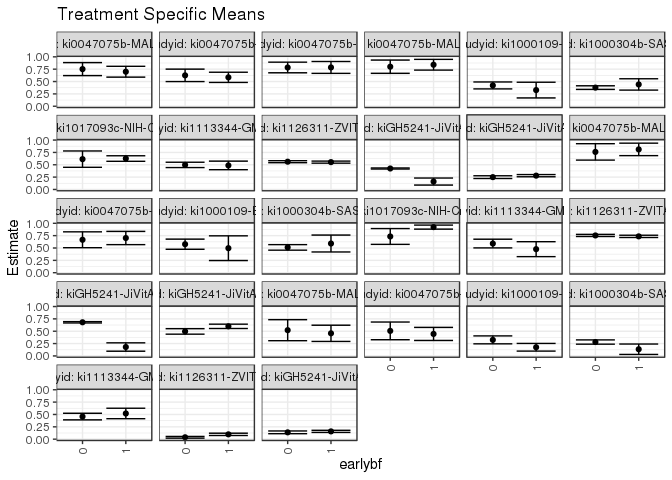

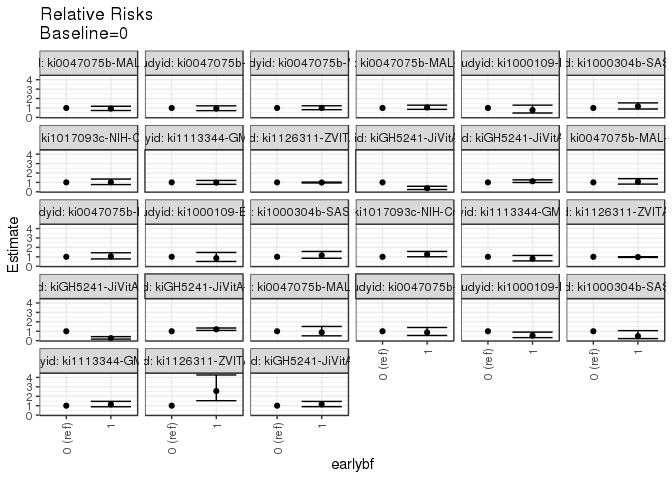

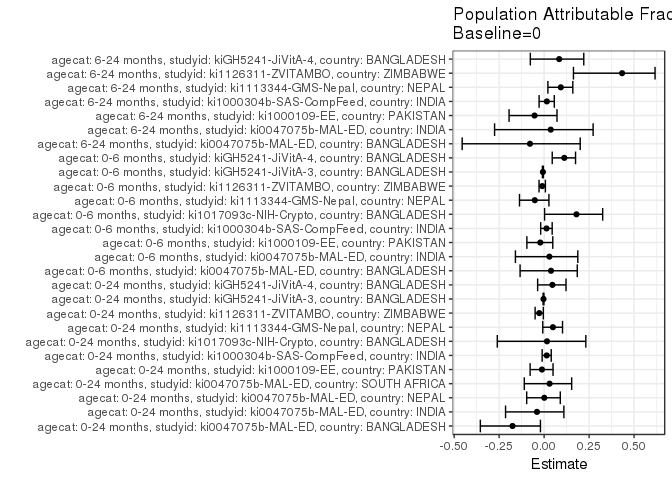

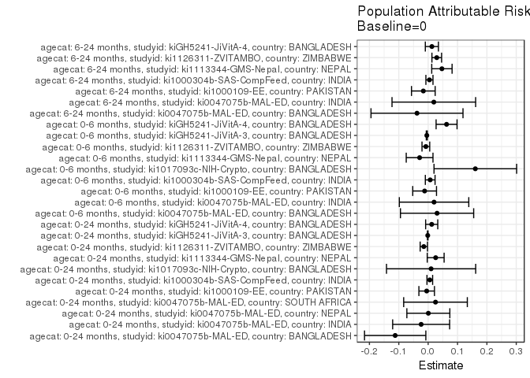

## Results Table

### Parameter: TSM

| agecat | studyid | country | intervention_level | baseline_level | estimate | ci_lower | ci_upper |
| --- | --- | --- | --- | --- | --- | --- | --- |
| 0-24 months | ki0047075b-MAL-ED | BANGLADESH | 0 | NA | 0.7516548 | 0.6199060 | 0.8834035 |
| 0-24 months | ki0047075b-MAL-ED | BANGLADESH | 1 | NA | 0.6985407 | 0.5890993 | 0.8079821 |
| 0-24 months | ki0047075b-MAL-ED | INDIA | 0 | NA | 0.6250000 | 0.4991100 | 0.7508900 |
| 0-24 months | ki0047075b-MAL-ED | INDIA | 1 | NA | 0.5849057 | 0.4818334 | 0.6879779 |
| 0-24 months | ki0047075b-MAL-ED | NEPAL | 0 | NA | 0.7843137 | 0.6765475 | 0.8920799 |
| 0-24 months | ki0047075b-MAL-ED | NEPAL | 1 | NA | 0.7857143 | 0.6655613 | 0.9058673 |
| 0-24 months | ki0047075b-MAL-ED | SOUTH AFRICA | 0 | NA | 0.8000000 | 0.6657395 | 0.9342605 |
| 0-24 months | ki0047075b-MAL-ED | SOUTH AFRICA | 1 | NA | 0.8400000 | 0.7318211 | 0.9481789 |
| 0-24 months | ki1000109-EE | PAKISTAN | 0 | NA | 0.4213897 | 0.3512965 | 0.4914829 |
| 0-24 months | ki1000109-EE | PAKISTAN | 1 | NA | 0.3270362 | 0.1680885 | 0.4859839 |
| 0-24 months | ki1000304b-SAS-CompFeed | INDIA | 0 | NA | 0.3771389 | 0.3407817 | 0.4134962 |
| 0-24 months | ki1000304b-SAS-CompFeed | INDIA | 1 | NA | 0.4411894 | 0.3263396 | 0.5560393 |
| 0-24 months | ki1017093c-NIH-Crypto | BANGLADESH | 0 | NA | 0.6137913 | 0.4486323 | 0.7789502 |
| 0-24 months | ki1017093c-NIH-Crypto | BANGLADESH | 1 | NA | 0.6263736 | 0.5704826 | 0.6822645 |
| 0-24 months | ki1113344-GMS-Nepal | NEPAL | 0 | NA | 0.4971980 | 0.4432393 | 0.5511566 |
| 0-24 months | ki1113344-GMS-Nepal | NEPAL | 1 | NA | 0.4867654 | 0.4000050 | 0.5735258 |
| 0-24 months | ki1126311-ZVITAMBO | ZIMBABWE | 0 | NA | 0.5620638 | 0.5415470 | 0.5825806 |
| 0-24 months | ki1126311-ZVITAMBO | ZIMBABWE | 1 | NA | 0.5534530 | 0.5325369 | 0.5743691 |
| 0-24 months | kiGH5241-JiVitA-3 | BANGLADESH | 0 | NA | 0.4244191 | 0.4132523 | 0.4355859 |
| 0-24 months | kiGH5241-JiVitA-3 | BANGLADESH | 1 | NA | 0.1603069 | 0.0892534 | 0.2313604 |
| 0-24 months | kiGH5241-JiVitA-4 | BANGLADESH | 0 | NA | 0.2498279 | 0.2222332 | 0.2774226 |
| 0-24 months | kiGH5241-JiVitA-4 | BANGLADESH | 1 | NA | 0.2797879 | 0.2575531 | 0.3020228 |
| 0-6 months | ki0047075b-MAL-ED | BANGLADESH | 0 | NA | 0.7600000 | 0.5939976 | 0.9260024 |
| 0-6 months | ki0047075b-MAL-ED | BANGLADESH | 1 | NA | 0.8108108 | 0.6847315 | 0.9368901 |
| 0-6 months | ki0047075b-MAL-ED | INDIA | 0 | NA | 0.6666788 | 0.5062001 | 0.8271575 |
| 0-6 months | ki0047075b-MAL-ED | INDIA | 1 | NA | 0.7021189 | 0.5683779 | 0.8358600 |
| 0-6 months | ki1000109-EE | PAKISTAN | 0 | NA | 0.5768770 | 0.4745023 | 0.6792517 |
| 0-6 months | ki1000109-EE | PAKISTAN | 1 | NA | 0.4962300 | 0.2464513 | 0.7460087 |
| 0-6 months | ki1000304b-SAS-CompFeed | INDIA | 0 | NA | 0.5123537 | 0.4561904 | 0.5685170 |
| 0-6 months | ki1000304b-SAS-CompFeed | INDIA | 1 | NA | 0.5903962 | 0.4192645 | 0.7615278 |
| 0-6 months | ki1017093c-NIH-Crypto | BANGLADESH | 0 | NA | 0.7333333 | 0.5730670 | 0.8935997 |
| 0-6 months | ki1017093c-NIH-Crypto | BANGLADESH | 1 | NA | 0.9226190 | 0.8817191 | 0.9635190 |
| 0-6 months | ki1113344-GMS-Nepal | NEPAL | 0 | NA | 0.5901079 | 0.5022635 | 0.6779523 |
| 0-6 months | ki1113344-GMS-Nepal | NEPAL | 1 | NA | 0.4763611 | 0.3252212 | 0.6275010 |
| 0-6 months | ki1126311-ZVITAMBO | ZIMBABWE | 0 | NA | 0.7538929 | 0.7326260 | 0.7751597 |
| 0-6 months | ki1126311-ZVITAMBO | ZIMBABWE | 1 | NA | 0.7353833 | 0.7126060 | 0.7581606 |
| 0-6 months | kiGH5241-JiVitA-3 | BANGLADESH | 0 | NA | 0.6810457 | 0.6676936 | 0.6943977 |
| 0-6 months | kiGH5241-JiVitA-3 | BANGLADESH | 1 | NA | 0.1805908 | 0.0959393 | 0.2652424 |
| 0-6 months | kiGH5241-JiVitA-4 | BANGLADESH | 0 | NA | 0.4960859 | 0.4403039 | 0.5518679 |
| 0-6 months | kiGH5241-JiVitA-4 | BANGLADESH | 1 | NA | 0.5991401 | 0.5555157 | 0.6427644 |
| 6-24 months | ki0047075b-MAL-ED | BANGLADESH | 0 | NA | 0.5213518 | 0.3086932 | 0.7340105 |
| 6-24 months | ki0047075b-MAL-ED | BANGLADESH | 1 | NA | 0.4574964 | 0.2931380 | 0.6218547 |
| 6-24 months | ki0047075b-MAL-ED | INDIA | 0 | NA | 0.5070232 | 0.3280117 | 0.6860347 |
| 6-24 months | ki0047075b-MAL-ED | INDIA | 1 | NA | 0.4453053 | 0.3129056 | 0.5777049 |
| 6-24 months | ki1000109-EE | PAKISTAN | 0 | NA | 0.3251591 | 0.2446923 | 0.4056258 |
| 6-24 months | ki1000109-EE | PAKISTAN | 1 | NA | 0.1754143 | 0.0974339 | 0.2533948 |
| 6-24 months | ki1000304b-SAS-CompFeed | INDIA | 0 | NA | 0.2810790 | 0.2379292 | 0.3242289 |
| 6-24 months | ki1000304b-SAS-CompFeed | INDIA | 1 | NA | 0.1356263 | 0.0301828 | 0.2410699 |
| 6-24 months | ki1113344-GMS-Nepal | NEPAL | 0 | NA | 0.4575738 | 0.3907714 | 0.5243761 |
| 6-24 months | ki1113344-GMS-Nepal | NEPAL | 1 | NA | 0.5198506 | 0.4138819 | 0.6258192 |
| 6-24 months | ki1126311-ZVITAMBO | ZIMBABWE | 0 | NA | 0.0382488 | 0.0208636 | 0.0556341 |
| 6-24 months | ki1126311-ZVITAMBO | ZIMBABWE | 1 | NA | 0.0975692 | 0.0741628 | 0.1209757 |
| 6-24 months | kiGH5241-JiVitA-4 | BANGLADESH | 0 | NA | 0.1380677 | 0.1102759 | 0.1658595 |
| 6-24 months | kiGH5241-JiVitA-4 | BANGLADESH | 1 | NA | 0.1573701 | 0.1361640 | 0.1785763 |

### Parameter: E(Y)

| agecat | studyid | country | intervention_level | baseline_level | estimate | ci_lower | ci_upper |
| --- | --- | --- | --- | --- | --- | --- | --- |
| 0-24 months | ki0047075b-MAL-ED | BANGLADESH | NA | NA | 0.6393443 | 0.5524803 | 0.7262082 |
| 0-24 months | ki0047075b-MAL-ED | INDIA | NA | NA | 0.6011236 | 0.5212729 | 0.6809743 |
| 0-24 months | ki0047075b-MAL-ED | NEPAL | NA | NA | 0.7849462 | 0.7049947 | 0.8648978 |
| 0-24 months | ki0047075b-MAL-ED | SOUTH AFRICA | NA | NA | 0.8250000 | 0.7407860 | 0.9092140 |
| 0-24 months | ki1000109-EE | PAKISTAN | NA | NA | 0.4163424 | 0.3511349 | 0.4815500 |
| 0-24 months | ki1000304b-SAS-CompFeed | INDIA | NA | NA | 0.3827160 | 0.3474971 | 0.4179350 |
| 0-24 months | ki1017093c-NIH-Crypto | BANGLADESH | NA | NA | 0.6237942 | 0.5698223 | 0.6777662 |
| 0-24 months | ki1113344-GMS-Nepal | NEPAL | NA | NA | 0.5227723 | 0.4753649 | 0.5701796 |
| 0-24 months | ki1126311-ZVITAMBO | ZIMBABWE | NA | NA | 0.5472806 | 0.5299898 | 0.5645714 |
| 0-24 months | kiGH5241-JiVitA-3 | BANGLADESH | NA | NA | 0.4229803 | 0.4118532 | 0.4341074 |
| 0-24 months | kiGH5241-JiVitA-4 | BANGLADESH | NA | NA | 0.2618872 | 0.2425585 | 0.2812158 |
| 0-6 months | ki0047075b-MAL-ED | BANGLADESH | NA | NA | 0.7903226 | 0.6894772 | 0.8911679 |
| 0-6 months | ki0047075b-MAL-ED | INDIA | NA | NA | 0.6867470 | 0.5837430 | 0.7897510 |
| 0-6 months | ki1000109-EE | PAKISTAN | NA | NA | 0.5648148 | 0.4692893 | 0.6603404 |
| 0-6 months | ki1000304b-SAS-CompFeed | INDIA | NA | NA | 0.5192878 | 0.4654446 | 0.5731311 |
| 0-6 months | ki1017093c-NIH-Crypto | BANGLADESH | NA | NA | 0.8939394 | 0.8505280 | 0.9373508 |
| 0-6 months | ki1113344-GMS-Nepal | NEPAL | NA | NA | 0.5609756 | 0.4845156 | 0.6374356 |
| 0-6 months | ki1126311-ZVITAMBO | ZIMBABWE | NA | NA | 0.7460664 | 0.7282412 | 0.7638917 |
| 0-6 months | kiGH5241-JiVitA-3 | BANGLADESH | NA | NA | 0.6764644 | 0.6631306 | 0.6897982 |
| 0-6 months | kiGH5241-JiVitA-4 | BANGLADESH | NA | NA | 0.5587703 | 0.5173487 | 0.6001920 |
| 6-24 months | ki0047075b-MAL-ED | BANGLADESH | NA | NA | 0.4833333 | 0.3508378 | 0.6158289 |
| 6-24 months | ki0047075b-MAL-ED | INDIA | NA | NA | 0.5263158 | 0.4116286 | 0.6410029 |
| 6-24 months | ki1000109-EE | PAKISTAN | NA | NA | 0.3087248 | 0.2336906 | 0.3837591 |
| 6-24 months | ki1000304b-SAS-CompFeed | INDIA | NA | NA | 0.2854123 | 0.2436284 | 0.3271961 |
| 6-24 months | ki1113344-GMS-Nepal | NEPAL | NA | NA | 0.5043988 | 0.4461732 | 0.5626244 |
| 6-24 months | ki1126311-ZVITAMBO | ZIMBABWE | NA | NA | 0.0675105 | 0.0516864 | 0.0833347 |
| 6-24 months | kiGH5241-JiVitA-4 | BANGLADESH | NA | NA | 0.1506942 | 0.1331077 | 0.1682807 |

### Parameter: RR

| agecat | studyid | country | intervention_level | baseline_level | estimate | ci_lower | ci_upper |
| --- | --- | --- | --- | --- | --- | --- | --- |
| 0-24 months | ki0047075b-MAL-ED | BANGLADESH | 0 | 0 | 1.0000000 | 1.0000000 | 1.0000000 |
| 0-24 months | ki0047075b-MAL-ED | BANGLADESH | 1 | 0 | 0.9293372 | 0.7319773 | 1.1799103 |
| 0-24 months | ki0047075b-MAL-ED | INDIA | 0 | 0 | 1.0000000 | 1.0000000 | 1.0000000 |
| 0-24 months | ki0047075b-MAL-ED | INDIA | 1 | 0 | 0.9358491 | 0.7160967 | 1.2230380 |
| 0-24 months | ki0047075b-MAL-ED | NEPAL | 0 | 0 | 1.0000000 | 1.0000000 | 1.0000000 |
| 0-24 months | ki0047075b-MAL-ED | NEPAL | 1 | 0 | 1.0017857 | 0.8150417 | 1.2313168 |
| 0-24 months | ki0047075b-MAL-ED | SOUTH AFRICA | 0 | 0 | 1.0000000 | 1.0000000 | 1.0000000 |
| 0-24 months | ki0047075b-MAL-ED | SOUTH AFRICA | 1 | 0 | 1.0500000 | 0.8496502 | 1.2975928 |
| 0-24 months | ki1000109-EE | PAKISTAN | 0 | 0 | 1.0000000 | 1.0000000 | 1.0000000 |
| 0-24 months | ki1000109-EE | PAKISTAN | 1 | 0 | 0.7760897 | 0.4649348 | 1.2954834 |
| 0-24 months | ki1000304b-SAS-CompFeed | INDIA | 0 | 0 | 1.0000000 | 1.0000000 | 1.0000000 |
| 0-24 months | ki1000304b-SAS-CompFeed | INDIA | 1 | 0 | 1.1698326 | 0.8894999 | 1.5385143 |
| 0-24 months | ki1017093c-NIH-Crypto | BANGLADESH | 0 | 0 | 1.0000000 | 1.0000000 | 1.0000000 |
| 0-24 months | ki1017093c-NIH-Crypto | BANGLADESH | 1 | 0 | 1.0204994 | 0.7704784 | 1.3516525 |
| 0-24 months | ki1113344-GMS-Nepal | NEPAL | 0 | 0 | 1.0000000 | 1.0000000 | 1.0000000 |
| 0-24 months | ki1113344-GMS-Nepal | NEPAL | 1 | 0 | 0.9790173 | 0.7946548 | 1.2061524 |
| 0-24 months | ki1126311-ZVITAMBO | ZIMBABWE | 0 | 0 | 1.0000000 | 1.0000000 | 1.0000000 |
| 0-24 months | ki1126311-ZVITAMBO | ZIMBABWE | 1 | 0 | 0.9846801 | 0.9413209 | 1.0300365 |
| 0-24 months | kiGH5241-JiVitA-3 | BANGLADESH | 0 | 0 | 1.0000000 | 1.0000000 | 1.0000000 |
| 0-24 months | kiGH5241-JiVitA-3 | BANGLADESH | 1 | 0 | 0.3777090 | 0.2422867 | 0.5888234 |
| 0-24 months | kiGH5241-JiVitA-4 | BANGLADESH | 0 | 0 | 1.0000000 | 1.0000000 | 1.0000000 |
| 0-24 months | kiGH5241-JiVitA-4 | BANGLADESH | 1 | 0 | 1.1199229 | 0.9892643 | 1.2678384 |
| 0-6 months | ki0047075b-MAL-ED | BANGLADESH | 0 | 0 | 1.0000000 | 1.0000000 | 1.0000000 |
| 0-6 months | ki0047075b-MAL-ED | BANGLADESH | 1 | 0 | 1.0668563 | 0.8159358 | 1.3949411 |
| 0-6 months | ki0047075b-MAL-ED | INDIA | 0 | 0 | 1.0000000 | 1.0000000 | 1.0000000 |
| 0-6 months | ki0047075b-MAL-ED | INDIA | 1 | 0 | 1.0531592 | 0.7747780 | 1.4315641 |
| 0-6 months | ki1000109-EE | PAKISTAN | 0 | 0 | 1.0000000 | 1.0000000 | 1.0000000 |
| 0-6 months | ki1000109-EE | PAKISTAN | 1 | 0 | 0.8602008 | 0.5058827 | 1.4626817 |
| 0-6 months | ki1000304b-SAS-CompFeed | INDIA | 0 | 0 | 1.0000000 | 1.0000000 | 1.0000000 |
| 0-6 months | ki1000304b-SAS-CompFeed | INDIA | 1 | 0 | 1.1523214 | 0.8465035 | 1.5686228 |
| 0-6 months | ki1017093c-NIH-Crypto | BANGLADESH | 0 | 0 | 1.0000000 | 1.0000000 | 1.0000000 |
| 0-6 months | ki1017093c-NIH-Crypto | BANGLADESH | 1 | 0 | 1.2581169 | 1.0066423 | 1.5724137 |
| 0-6 months | ki1113344-GMS-Nepal | NEPAL | 0 | 0 | 1.0000000 | 1.0000000 | 1.0000000 |
| 0-6 months | ki1113344-GMS-Nepal | NEPAL | 1 | 0 | 0.8072440 | 0.5686670 | 1.1459129 |
| 0-6 months | ki1126311-ZVITAMBO | ZIMBABWE | 0 | 0 | 1.0000000 | 1.0000000 | 1.0000000 |
| 0-6 months | ki1126311-ZVITAMBO | ZIMBABWE | 1 | 0 | 0.9754480 | 0.9393175 | 1.0129684 |
| 0-6 months | kiGH5241-JiVitA-3 | BANGLADESH | 0 | 0 | 1.0000000 | 1.0000000 | 1.0000000 |
| 0-6 months | kiGH5241-JiVitA-3 | BANGLADESH | 1 | 0 | 0.2651670 | 0.1658776 | 0.4238880 |
| 0-6 months | kiGH5241-JiVitA-4 | BANGLADESH | 0 | 0 | 1.0000000 | 1.0000000 | 1.0000000 |
| 0-6 months | kiGH5241-JiVitA-4 | BANGLADESH | 1 | 0 | 1.2077345 | 1.0847194 | 1.3447003 |
| 6-24 months | ki0047075b-MAL-ED | BANGLADESH | 0 | 0 | 1.0000000 | 1.0000000 | 1.0000000 |
| 6-24 months | ki0047075b-MAL-ED | BANGLADESH | 1 | 0 | 0.8775194 | 0.5109090 | 1.5071967 |
| 6-24 months | ki0047075b-MAL-ED | INDIA | 0 | 0 | 1.0000000 | 1.0000000 | 1.0000000 |
| 6-24 months | ki0047075b-MAL-ED | INDIA | 1 | 0 | 0.8782738 | 0.5512344 | 1.3993411 |
| 6-24 months | ki1000109-EE | PAKISTAN | 0 | 0 | 1.0000000 | 1.0000000 | 1.0000000 |
| 6-24 months | ki1000109-EE | PAKISTAN | 1 | 0 | 0.5394723 | 0.3213188 | 0.9057371 |
| 6-24 months | ki1000304b-SAS-CompFeed | INDIA | 0 | 0 | 1.0000000 | 1.0000000 | 1.0000000 |
| 6-24 months | ki1000304b-SAS-CompFeed | INDIA | 1 | 0 | 0.4825202 | 0.2189398 | 1.0634236 |
| 6-24 months | ki1113344-GMS-Nepal | NEPAL | 0 | 0 | 1.0000000 | 1.0000000 | 1.0000000 |
| 6-24 months | ki1113344-GMS-Nepal | NEPAL | 1 | 0 | 1.1361022 | 0.8865221 | 1.4559459 |
| 6-24 months | ki1126311-ZVITAMBO | ZIMBABWE | 0 | 0 | 1.0000000 | 1.0000000 | 1.0000000 |
| 6-24 months | ki1126311-ZVITAMBO | ZIMBABWE | 1 | 0 | 2.5509065 | 1.5271492 | 4.2609615 |
| 6-24 months | kiGH5241-JiVitA-4 | BANGLADESH | 0 | 0 | 1.0000000 | 1.0000000 | 1.0000000 |
| 6-24 months | kiGH5241-JiVitA-4 | BANGLADESH | 1 | 0 | 1.1398041 | 0.8945575 | 1.4522862 |

### Parameter: PAR

| agecat | studyid | country | intervention_level | baseline_level | estimate | ci_lower | ci_upper |
| --- | --- | --- | --- | --- | --- | --- | --- |
| 0-24 months | ki0047075b-MAL-ED | BANGLADESH | 0 | NA | -0.1123105 | -0.2167159 | -0.0079051 |
| 0-24 months | ki0047075b-MAL-ED | INDIA | 0 | NA | -0.0238764 | -0.1208814 | 0.0731286 |
| 0-24 months | ki0047075b-MAL-ED | NEPAL | 0 | NA | 0.0006325 | -0.0725325 | 0.0737975 |
| 0-24 months | ki0047075b-MAL-ED | SOUTH AFRICA | 0 | NA | 0.0250000 | -0.0833539 | 0.1333539 |
| 0-24 months | ki1000109-EE | PAKISTAN | 0 | NA | -0.0050473 | -0.0315228 | 0.0214282 |
| 0-24 months | ki1000304b-SAS-CompFeed | INDIA | 0 | NA | 0.0055771 | -0.0040797 | 0.0152339 |
| 0-24 months | ki1017093c-NIH-Crypto | BANGLADESH | 0 | NA | 0.0100030 | -0.1418333 | 0.1618392 |
| 0-24 months | ki1113344-GMS-Nepal | NEPAL | 0 | NA | 0.0255743 | -0.0031759 | 0.0543244 |
| 0-24 months | ki1126311-ZVITAMBO | ZIMBABWE | 0 | NA | -0.0147832 | -0.0272160 | -0.0023503 |
| 0-24 months | kiGH5241-JiVitA-3 | BANGLADESH | 0 | NA | -0.0014388 | -0.0024138 | -0.0004638 |
| 0-24 months | kiGH5241-JiVitA-4 | BANGLADESH | 0 | NA | 0.0120593 | -0.0085878 | 0.0327064 |
| 0-6 months | ki0047075b-MAL-ED | BANGLADESH | 0 | NA | 0.0303226 | -0.0943770 | 0.1550222 |
| 0-6 months | ki0047075b-MAL-ED | INDIA | 0 | NA | 0.0200682 | -0.0981933 | 0.1383297 |
| 0-6 months | ki1000109-EE | PAKISTAN | 0 | NA | -0.0120622 | -0.0525530 | 0.0284286 |
| 0-6 months | ki1000304b-SAS-CompFeed | INDIA | 0 | NA | 0.0069341 | -0.0096374 | 0.0235056 |
| 0-6 months | ki1017093c-NIH-Crypto | BANGLADESH | 0 | NA | 0.1606061 | 0.0199418 | 0.3012703 |
| 0-6 months | ki1113344-GMS-Nepal | NEPAL | 0 | NA | -0.0291323 | -0.0746713 | 0.0164066 |
| 0-6 months | ki1126311-ZVITAMBO | ZIMBABWE | 0 | NA | -0.0078264 | -0.0209751 | 0.0053222 |
| 0-6 months | kiGH5241-JiVitA-3 | BANGLADESH | 0 | NA | -0.0045813 | -0.0063764 | -0.0027862 |
| 0-6 months | kiGH5241-JiVitA-4 | BANGLADESH | 0 | NA | 0.0626844 | 0.0270346 | 0.0983342 |
| 6-24 months | ki0047075b-MAL-ED | BANGLADESH | 0 | NA | -0.0380185 | -0.1946486 | 0.1186116 |
| 6-24 months | ki0047075b-MAL-ED | INDIA | 0 | NA | 0.0192925 | -0.1230781 | 0.1616632 |
| 6-24 months | ki1000109-EE | PAKISTAN | 0 | NA | -0.0164342 | -0.0567500 | 0.0238815 |
| 6-24 months | ki1000304b-SAS-CompFeed | INDIA | 0 | NA | 0.0043332 | -0.0077385 | 0.0164050 |
| 6-24 months | ki1113344-GMS-Nepal | NEPAL | 0 | NA | 0.0468251 | 0.0121767 | 0.0814735 |
| 6-24 months | ki1126311-ZVITAMBO | ZIMBABWE | 0 | NA | 0.0292617 | 0.0128152 | 0.0457082 |
| 6-24 months | kiGH5241-JiVitA-4 | BANGLADESH | 0 | NA | 0.0126265 | -0.0096666 | 0.0349196 |

### Parameter: PAF

| agecat | studyid | country | intervention_level | baseline_level | estimate | ci_lower | ci_upper |
| --- | --- | --- | --- | --- | --- | --- | --- |
| 0-24 months | ki0047075b-MAL-ED | BANGLADESH | 0 | NA | -0.1756652 | -0.3544701 | -0.0204644 |
| 0-24 months | ki0047075b-MAL-ED | INDIA | 0 | NA | -0.0397196 | -0.2143655 | 0.1098093 |
| 0-24 months | ki0047075b-MAL-ED | NEPAL | 0 | NA | 0.0008058 | -0.0968894 | 0.0897997 |
| 0-24 months | ki0047075b-MAL-ED | SOUTH AFRICA | 0 | NA | 0.0303030 | -0.1102301 | 0.1530474 |
| 0-24 months | ki1000109-EE | PAKISTAN | 0 | NA | -0.0121230 | -0.0778073 | 0.0495585 |
| 0-24 months | ki1000304b-SAS-CompFeed | INDIA | 0 | NA | 0.0145724 | -0.0109983 | 0.0394965 |
| 0-24 months | ki1017093c-NIH-Crypto | BANGLADESH | 0 | NA | 0.0160357 | -0.2602694 | 0.2317629 |
| 0-24 months | ki1113344-GMS-Nepal | NEPAL | 0 | NA | 0.0489205 | -0.0076055 | 0.1022755 |
| 0-24 months | ki1126311-ZVITAMBO | ZIMBABWE | 0 | NA | -0.0270121 | -0.0500651 | -0.0044652 |
| 0-24 months | kiGH5241-JiVitA-3 | BANGLADESH | 0 | NA | -0.0034015 | -0.0057112 | -0.0010971 |
| 0-24 months | kiGH5241-JiVitA-4 | BANGLADESH | 0 | NA | 0.0460477 | -0.0360433 | 0.1216342 |
| 0-6 months | ki0047075b-MAL-ED | BANGLADESH | 0 | NA | 0.0383673 | -0.1336084 | 0.1842533 |
| 0-6 months | ki0047075b-MAL-ED | INDIA | 0 | NA | 0.0292221 | -0.1595167 | 0.1872392 |
| 0-6 months | ki1000109-EE | PAKISTAN | 0 | NA | -0.0213560 | -0.0958600 | 0.0480827 |
| 0-6 months | ki1000304b-SAS-CompFeed | INDIA | 0 | NA | 0.0133531 | -0.0190961 | 0.0447691 |
| 0-6 months | ki1017093c-NIH-Crypto | BANGLADESH | 0 | NA | 0.1796610 | 0.0024658 | 0.3253805 |
| 0-6 months | ki1113344-GMS-Nepal | NEPAL | 0 | NA | -0.0519315 | -0.1368790 | 0.0266687 |
| 0-6 months | ki1126311-ZVITAMBO | ZIMBABWE | 0 | NA | -0.0104903 | -0.0282915 | 0.0070028 |
| 0-6 months | kiGH5241-JiVitA-3 | BANGLADESH | 0 | NA | -0.0067724 | -0.0094406 | -0.0041113 |
| 0-6 months | kiGH5241-JiVitA-4 | BANGLADESH | 0 | NA | 0.1121828 | 0.0450796 | 0.1745705 |
| 6-24 months | ki0047075b-MAL-ED | BANGLADESH | 0 | NA | -0.0786590 | -0.4554321 | 0.2005775 |
| 6-24 months | ki0047075b-MAL-ED | INDIA | 0 | NA | 0.0366558 | -0.2753556 | 0.2723347 |
| 6-24 months | ki1000109-EE | PAKISTAN | 0 | NA | -0.0532326 | -0.1948567 | 0.0716051 |
| 6-24 months | ki1000304b-SAS-CompFeed | INDIA | 0 | NA | 0.0151823 | -0.0280275 | 0.0565759 |
| 6-24 months | ki1113344-GMS-Nepal | NEPAL | 0 | NA | 0.0928334 | 0.0209406 | 0.1594471 |
| 6-24 months | ki1126311-ZVITAMBO | ZIMBABWE | 0 | NA | 0.4334390 | 0.1630222 | 0.6164876 |
| 6-24 months | kiGH5241-JiVitA-4 | BANGLADESH | 0 | NA | 0.0837889 | -0.0766429 | 0.2203146 |